# Large Scale Time Series Machine Learning

Ming Ming Zhang

## Abstract

We implement stochastic gradient descent in R and apply it to a [large scale time series dataset](https://www.gov.uk/guidance/about-the-price-paid-data). Moreover, we provide a method for model evaluation which cab be used in the learning curve for time series data.

The data is about the UK government’s land registry. The objective is to predict the housing sale price. Since the purpose of this excecise is for the author’s learning, linear regression is used as the machine learning model. The sliding window time series analysis is used to evaluate the model. As the training size is large, our implemented algorithm stochastic gradient descent will be applied.

## Preprocess data

We preprocess the data and select relevant features.

```r
library(readr)

house = read_csv("~/Downloads/Data/UKHousing/pp-complete.csv", col_names = FALSE)
```

```r
names(house) = c("Id","Price","Date","Postcode","Type","Age","Duration","PAON","SAON","Street","Locality","City","District","County","PPD","Status")
dim(house)
```

```
[1] 24273716       16
```

```r
head(house)
```

| Id | Price | Date | Postcode | Type | Age | Duration | PAON | SAON | Street | Locality | City | District | County | PPD | Status |
| --- | --- | --- | --- | --- | --- | --- | --- | --- | --- | --- | --- | --- | --- | --- | --- |
| {A42E2F04-2538-4A25-94C5-49E29C6C8FA8} | 18500 | 1995-01-31 | TQ1 1RY | F | N | L | VILLA PARADISO | FLAT 10 | HIGHER WARBERRY ROAD | TORQUAY | TORQUAY | TORBAY | TORBAY | A | A |
| {1BA349E3-2579-40D6-999E-49E2A25D2284} | 73450 | 1995-10-09 | L26 7XJ | D | Y | F | 6 | NA | CATKIN ROAD | LIVERPOOL | LIVERPOOL | KNOWSLEY | MERSEYSIDE | A | A |
| {E5B50DCB-BC7A-4E54-B167-49E2A6B4148B} | 59000 | 1995-03-31 | BH12 2AE | D | N | F | 28 | NA | ALDER ROAD | POOLE | POOLE | POOLE | POOLE | A | A |
| {81E50116-D675-4B7F-9F8D-49E2B5D43271} | 31000 | 1995-12-04 | IP13 0DR | D | Y | F | NONSUCH COTTAGE | NA | THE STREET | HACHESTON | WOODBRIDGE | SUFFOLK COASTAL | SUFFOLK | A | A |
| {B97455B9-75CB-40BB-A615-42C53683E143} | 95000 | 1995-09-22 | WS14 0BE | D | N | F | FOX COVER COTTAGE | NA | HALL LANE | LICHFIELD | LICHFIELD | LICHFIELD | STAFFORDSHIRE | A | A |
| {F0D1E8DA-C00D-467A-A41C-42C5378DB6E0} | 45450 | 1995-02-28 | S42 5GA | S | Y | F | 109 | NA | ELVASTON ROAD | NORTH WINGFIELD | CHESTERFIELD | NORTH EAST DERBYSHIRE | DERBYSHIRE | A | A |

```r
house = house[c("Price","Date","Type","Age","Duration","City")]
house = house[order(house$Date),]
house$Year = as.numeric(format(house$Date, "%Y"))
dim(house)
```

```
[1] 24273716        7
```

```r
head(house)
```

| Price | Date | Type | Age | Duration | City | Year |
| --- | --- | --- | --- | --- | --- | --- |
| 16000 | 1995-01-01 | T | N | F | HALIFAX | 1995 |
| 70500 | 1995-01-01 | S | N | F | HORSHAM | 1995 |
| 54000 | 1995-01-01 | T | N | F | BIRMINGHAM | 1995 |
| 97995 | 1995-01-01 | D | Y | F | RAYLEIGH | 1995 |
| 105000 | 1995-01-01 | S | N | F | BORDON | 1995 |
| 165500 | 1995-01-01 | D | N | F | BIRMINGHAM | 1995 |

```r
priceByYear = aggregate(house["Price"], by = house["Year"], FUN = mean)
head(priceByYear)
```

|  | Year | Price |
| --- | --- | --- |
| 1 | 1995 | 67922.29 |
| 2 | 1996 | 71495.86 |
| 3 | 1997 | 78519.55 |
| 4 | 1998 | 85425.60 |
| 5 | 1999 | 96022.12 |
| 6 | 2000 | 107460.37 |

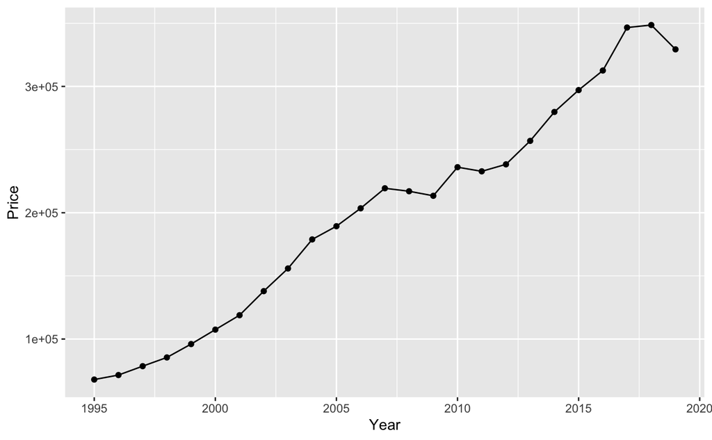

```r
library(ggplot2)
ggplot(priceByYear, aes(Year, Price)) +
  geom_point() + geom_line()
```

```r
yearList = priceByYear$Year
for (i in 1:length(yearList)) {
  house[,ncol(house)+1] = NA
  house[,ncol(house)] = ifelse(house$Year == yearList[i], 1, 0)
}
names(house)[8:ncol(house)] = paste("Y", yearList, sep = "")
```

```r
priceByType = aggregate(house["Price"], by = house["Type"], FUN = mean)
priceByType
```

| Type | Price |
| --- | --- |
| D | 261720.9 |
| F | 184618.7 |
| O | 1236201.3 |
| S | 156323.9 |
| T | 143148.8 |

```r
typeList = priceByType$Type
for (i in 1:length(typeList)) {
  house[,ncol(house)+1] = NA
  house[,ncol(house)] = ifelse(house$Type == typeList[i], 1, 0)
}
names(house)[33:ncol(house)] = paste("Type", typeList, sep = "")
```

```r
priceByAge = aggregate(house["Price"], by = house["Age"], FUN = mean)
priceByAge
```

| Age | Price |
| --- | --- |
| N | 190628.8 |
| Y | 200119.7 |

```r
ageList = priceByAge$Age
for (i in 1:length(ageList)) {
  house[,ncol(house)+1] = NA
  house[,ncol(house)] = ifelse(house$Age == ageList[i], 1, 0)
}
names(house)[38:ncol(house)] = paste("Age", ageList, sep = "")
```

```r
priceByDuration = aggregate(house["Price"], by = house["Duration"], FUN = mean)
priceByDuration
```

| Duration | Price |
| --- | --- |
| F | 195437.8 |
| L | 179306.5 |
| U | 163419.4 |

```r
durationList = priceByDuration$Duration
for (i in 1:length(durationList)) {
  house[,ncol(house)+1] = NA
  house[,ncol(house)] = ifelse(house$Duration == durationList[i], 1, 0)
}
names(house)[40:ncol(house)] = paste("Duration", durationList, sep = "")
```

### Save data

```r
house = house[, !names(house) %in% c("Date","Type","Age","Duration","Year")]
dim(house)
```

```
[1] 24273716       37
```

```r
write.csv(house, file = "~/Downloads/Data/UKHousing/house.csv")
```

## Load data

```r
library(ggplot2)
library(readr)

house = read_csv("~/Downloads/Data/UKHousing/house.csv", progress = F)
dim(house)
```

```
[1] 24273716       38
```

```r
object.size(house)
```

```
7379306336 bytes
```

```r
house$X1 = NULL
```

### Top cities

The top cities in sale price order:

```r
priceByCity = aggregate(house["Price"], by = house["City"], FUN = mean)
priceByCity = priceByCity[order(priceByCity$Price, decreasing = T),]
cityList = priceByCity$City
cat("Number of cities:", length(cityList),"\n\n")
```

```
Number of cities: 1171
```

```r
cat("Top 30 cities in sale price order:\n")
```

```
Top 30 cities in sale price order:
```

```r
cat(cityList[1:30], sep = ", ")
```

[output not shown]

```r
head(priceByCity)
```

|  | City | Price |
| --- | --- | --- |
| 408 | GATWICK | 18721427.0 |
| 1022 | THORNHILL | 985000.0 |
| 1063 | VIRGINIA WATER | 784997.9 |
| 228 | CHALFONT ST GILES | 764751.0 |
| 269 | COBHAM | 654772.3 |
| 77 | BEACONSFIELD | 626759.6 |

## Select city

Select cities and create corresponding binaray vectors such that 1 means the house is located in the city and 0 otherwise. Throughout the project, the city London is used as an extra feature to predict the sale price.

```r
house$London = ifelse(house$City == "LONDON", 1, 0)
```

```r
house = house[, !names(house) %in% "City"]
```

## Linear regression

### Learning curve

Note that the data is time series range from the year 1995 to 2019. First, we randomly select 100 examples in the year 2018 as the cross-validation set. Let $I = \{1,3,10,30,100,300\}$. Repeat the following process 5 times. For each $k \in I$, randomly select $k$ training examples from each year between 1995 and 2017, train linear regression with conjugate gradient, and then compute errors (MSE) on training and cross-validation set using the trained parameter. Lastly, average across errors for each $k$.

```r
L
```

```
$error_train
[1] 10469717923  9989752504  9828164314 45984316985 35246664177 55676762624

$error_val
[1]  57844271726 864441765989  49998353293 311692744822  60100046538  62127640845
```

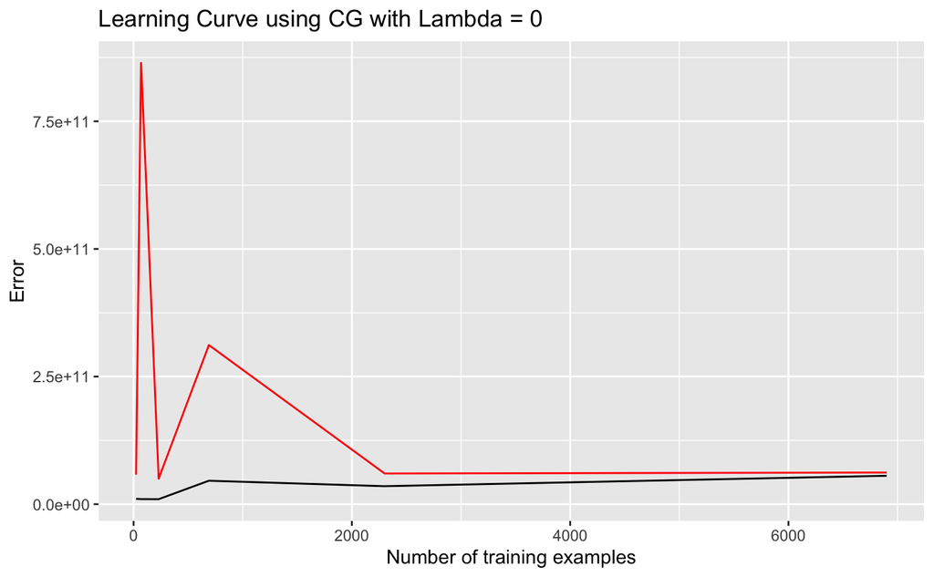

```r
library(ggplot2)
D = data.frame(x=c(1*length(1995:2017),3*length(1995:2017),10*length(1995:2017),30*length(1995:2017),100*length(1995:2017),300*length(1995:2017)), error_train=L[[1]], error_val=L[[2]])
ggplot(D, aes(x, error_train)) +
  geom_line() + geom_line(aes(x, error_val), color="red") +
  xlab("Number of training examples") + ylab("Error") +
  ggtitle(paste("Learning Curve using", method, "with Lambda =", lambda))
```

The learning curve indicates high bias and low variance.

### stochastic gradient descent

We will apply the silding window time series analysis to evaluate the model. Since the data has a large training examples for each sliding window, we will use stochastic gradient descent as the optimization function.

```r
k = 5
error_train = rep(0, k)
error_val = rep(0, k)
```

```
$par
                    TypeD        TypeF        TypeO        TypeS        TypeT         AgeN         AgeY    DurationF    DurationL
2.588534e+04 1.251653e+04 4.481351e+03 2.146194e+00 5.070756e+03 3.814553e+03 2.110186e+04 4.783476e+03 2.060425e+04 5.280450e+03
   DurationU       London
6.398589e-01 5.948537e+03

$figure
```

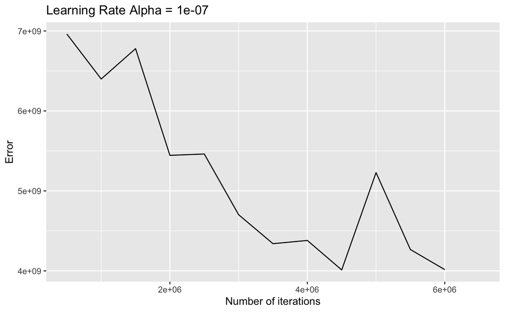

```r
k = 1

L = list()
for (j in which(names(house)=="Y1995"):which(names(house)=="Y2000")) {
  house_train = house[house[,j] == 1,]
  L[[j-1]] = house_train
}
house_train = L[[1]]
for (i in 2:length(L)) {
  house_train = rbind(house_train, L[[i]])
}
house_train = house_train[,c(1,which(names(house)=="TypeD"):ncol(house))]
house_train = house_train[sample(nrow(house_train)),]

XY_train = as.matrix(house_train)
X = XY_train[,-1]
y = XY_train[,1]

method = "SGD"
alpha = 1e-7
num_iter1 = 1
num_iter2 = 5e5
(fit = lrLearningSGD(X, y, alpha, num_iter1, num_iter2))
```

```r
theta = fit$par
error_train[k] = lrCost(cbind(1,X), y, theta, lambda = 0)[[1]]
format(error_train[k], digits = 2)
```

```
[1] "4.2e+09"
```

```r
house_val = house[(house$Y2001 == 1),]
house_val = house_val[,c(1,which(names(house)=="TypeD"):ncol(house))]
XY_val = as.matrix(house_val)
X_val = XY_val[,-1]
y_val = XY_val[,1]
error_val[k] = lrCost(cbind(1,X_val), y_val, theta, lambda = 0)[[1]]
format(error_val[k], digits = 2)
```

```
[1] "8.6e+09"
```

```r
rm(L)
rm(house_train)
rm(house_val)
rm(XY_train)
rm(X)
rm(y)
rm(XY_val)
rm(X_val)
rm(y_val)
```

```
$par
                    TypeD        TypeF        TypeO        TypeS        TypeT         AgeN         AgeY    DurationF    DurationL
47171.872813 21482.825925  9846.337413     9.786831  9098.493327  6734.429317 38975.023009  8196.849804 36230.966122 10936.151936
   DurationU       London
    4.754754 10537.385080

$figure
```

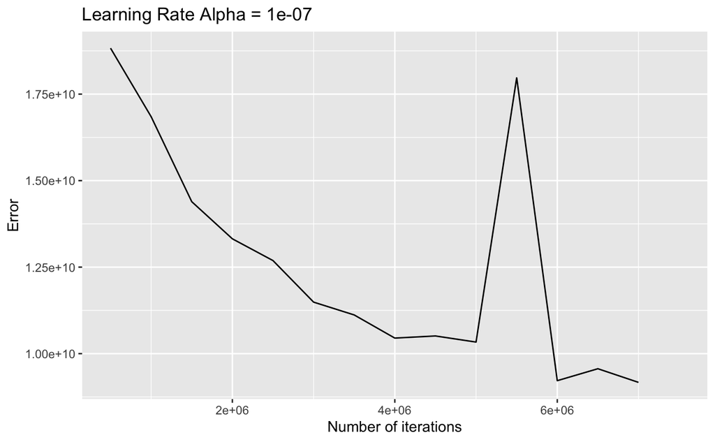

```r
k = 2

L = list()
for (j in which(names(house)=="Y2000"):which(names(house)=="Y2005")) {
  house_train = house[house[,j] == 1,]
  L[[j-1]] = house_train
}
house_train = L[[1]]
for (i in 2:length(L)) {
  house_train = rbind(house_train, L[[i]])
}
house_train = house_train[,c(1,which(names(house)=="TypeD"):ncol(house))]
house_train = house_train[sample(1:nrow(house_train)),]

XY_train = as.matrix(house_train)
X = XY_train[,-1]
y = XY_train[,1]

method = "SGD"
alpha = 1e-7
num_iter1 = 1
num_iter2 = 5e5
(fit = lrLearningSGD(X, y, alpha, num_iter1, num_iter2))
```

```r
theta = fit$par
error_train[k] = lrCost(cbind(1,X), y, theta, lambda = 0)[[1]]
format(error_train[k], digits = 2)
```

```
[1] "9.8e+09"
```

```r
house_val = house[house$Y2006 == 1,]
house_val = house_val[,c(1,which(names(house)=="TypeD"):ncol(house))]
XY_val = as.matrix(house_val)
X_val = XY_val[,-1]
y_val = XY_val[,1]
error_val[k] = lrCost(cbind(1,X_val), y_val, theta, lambda = 0)[[1]]
format(error_val[k], digits = 2)
```

```
[1] "1.7e+10"
```

```r
rm(L)
rm(house_train)
rm(house_val)
rm(XY_train)
rm(X)
rm(y)
rm(XY_val)
rm(X_val)
rm(y_val)
```

```
$par
                    TypeD        TypeF        TypeO        TypeS        TypeT         AgeN         AgeY    DurationF    DurationL
6.094562e+04 2.460082e+04 1.262373e+04 2.896777e+00 1.272555e+04 1.099263e+04 5.326458e+04 7.681048e+03 4.661949e+04 1.432529e+04
   DurationU       London
8.403072e-01 1.264356e+04

$figure
```

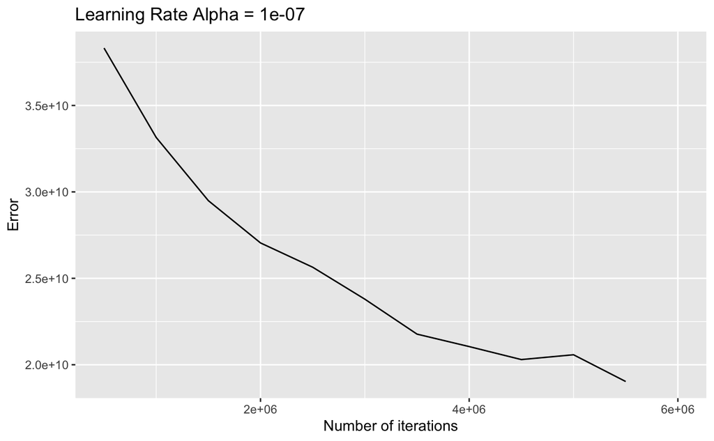

```r
k = 3

L = list()
for (j in which(names(house)=="Y2005"):which(names(house)=="Y2010")) {
  house_train = house[house[,j] == 1,]
  L[[j-1]] = house_train
}
house_train = L[[1]]
for (i in 2:length(L)) {
  house_train = rbind(house_train, L[[i]])
}
house_train = house_train[,c(1,which(names(house)=="TypeD"):ncol(house))]
house_train = house_train[sample(nrow(house_train)),]

XY_train = as.matrix(house_train)
X = XY_train[,-1]
y = XY_train[,1]

method = "SGD"
alpha = 1e-7
num_iter1 = 1
num_iter2 = 5e5
(fit = lrLearningSGD(X, y, alpha, num_iter1, num_iter2))
```

```r
theta = fit$par
error_train[k] = lrCost(cbind(1,X), y, theta, lambda = 0)[[1]]
format(error_train[k], digits = 2)
```

```
[1] "1.9e+10"
```

```r
house_val = house[house$Y2011 == 1,]
house_val = house_val[,c(1,which(names(house)=="TypeD"):ncol(house))]
XY_val = as.matrix(house_val)
X_val = XY_val[,-1]
y_val = XY_val[,1]
error_val[k] = lrCost(cbind(1,X_val), y_val, theta, lambda = 0)[[1]]
format(error_val[k], digits = 2)
```

```
[1] "3.8e+10"
```

```r
rm(L)
rm(house_train)
rm(house_val)
rm(XY_train)
rm(X)
rm(y)
rm(XY_val)
rm(X_val)
rm(y_val)
```

```
$par
              TypeD     TypeF     TypeO     TypeS     TypeT      AgeN      AgeY DurationF DurationL DurationU    London
70288.181 25331.364 14264.934  6294.375 12015.572 12381.936 62137.272  8150.909 52913.404 17374.777     0.000 20149.998

$figure
```

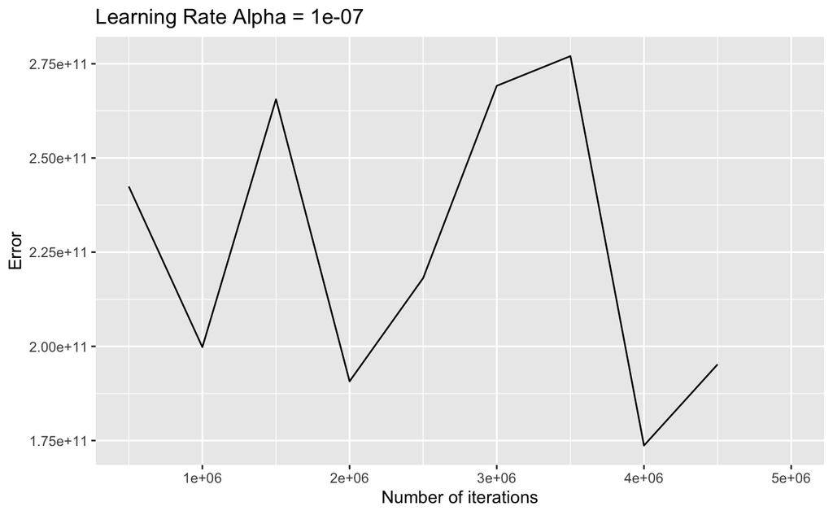

```r
k = 4

L = list()
for (j in which(names(house)=="Y2010"):which(names(house)=="Y2015")) {
  house_train = house[house[,j] == 1,]
  L[[j-1]] = house_train
}
house_train = L[[1]]
for (i in 2:length(L)) {
  house_train = rbind(house_train, L[[i]])
}
house_train = house_train[,c(1,which(names(house)=="TypeD"):ncol(house))]
house_train = house_train[sample(nrow(house_train)),]

XY_train = as.matrix(house_train)
X = XY_train[,-1]
y = XY_train[,1]

method = "SGD"
alpha = 1e-7
num_iter1 = 1
num_iter2 = 5e5
(fit = lrLearningSGD(X, y, alpha, num_iter1, num_iter2))
```

```r
theta = fit$par
error_train[k] = lrCost(cbind(1,X), y, theta, lambda = 0)[[1]]
format(error_train[k], digits = 2)
```

```
[1] "2.2e+11"
```

```r
house_val = house[house$Y2016 == 1,]
house_val = house_val[,c(1,which(names(house)=="TypeD"):ncol(house))]
XY_val = as.matrix(house_val)
X_val = XY_val[,-1]
y_val = XY_val[,1]
error_val[k] = lrCost(cbind(1,X_val), y_val, theta, lambda = 0)[[1]]
format(error_val[k], digits = 2)
```

```
[1] "6.5e+11"
```

```r
rm(L)
rm(house_train)
rm(house_val)
rm(XY_train)
rm(X)
rm(y)
rm(XY_val)
rm(X_val)
rm(y_val)
```

```
$par
                      TypeD         TypeF         TypeO         TypeS         TypeT          AgeN          AgeY     DurationF
1.827626e-288 5.132313e-289 3.215383e-289 2.664414e-289 3.541661e-289 3.722493e-289 1.627159e-288 2.004675e-289 1.389311e-288
    DurationL     DurationU        London
4.383151e-289  0.000000e+00 3.589734e-289

$figure
```

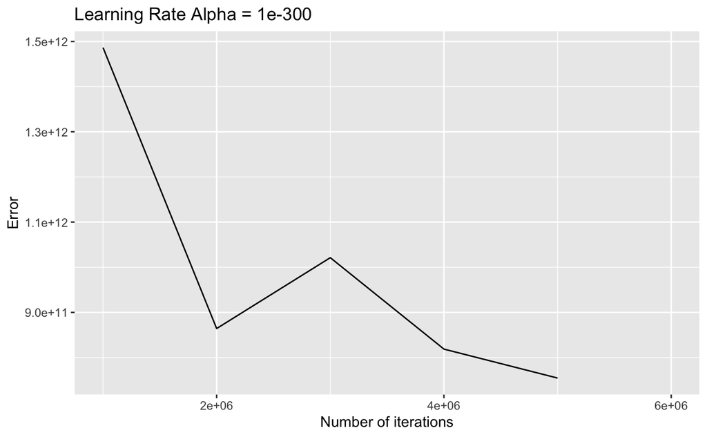

```r
method = "SGD"
alpha = 1e-300
num_iter1 = 1
num_iter2 = 1e6
(fit = lrLearningSGD(X, y, alpha, num_iter1, num_iter2))
```

```r
theta = fit$par
error_train[k] = lrCost(cbind(1,X), y, theta, lambda = 0)[[1]]
format(error_train[k], digits = 2)
```

```
[1] "9.6e+11"
```

```r
house_val = house[house$Y2019 == 1,]
house_val = house_val[,c(1,which(names(house)=="TypeD"):ncol(house))]
XY_val = as.matrix(house_val)
X_val = XY_val[,-1]
y_val = XY_val[,1]
error_val[k] = lrCost(cbind(1,X_val), y_val, theta, lambda = 0)[[1]]
format(error_val[k], digits = 2)
```

```
[1] "8.1e+11"
```

By taking the average of errors of sliding windows, the error of linear regression with stochastic gradient descent is

```r
format(mean(error_val), digits = 2)
```

```
[1] "3e+11"
```

Interestly, the error increases as the training window sildes.

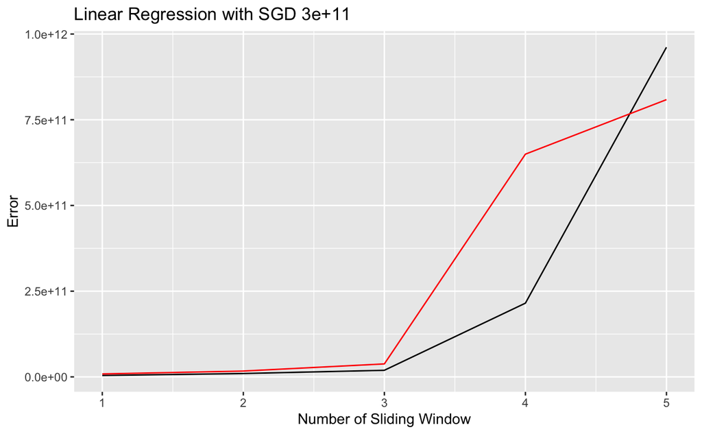

```r
ggplot(data.frame(m=1:k, x=error_train, y=error_val), aes(m,x)) +
  geom_line() + geom_line(aes(m,y), color="red") +
  xlab("Number of Sliding Window") + ylab("Error") +
  ggtitle(paste("Linear Regression with SGD", format(mean(error_val), digits = 2)))
```